# An Analysis of S&P 500 and Commodity Price Correlations

Reginal Supoint

2024-11-30

## Introduction

The purpose of this analysis is to explore the correlation between the S&P 500 index and various commodities such as oil, gold, silver, platinum and palladium. Understanding these correlations can provide insights into market dynamics and investment strategies.

This dataset includes daily closing prices for the S&P 500, NASDAQ, and several commodities. This analysis will include correlation analysis, time series forecasting and scenario analysis to understand potential future trends.

```r
# Select relevant columns for correlation analysis
cor_data <- data_clean %>% select(sp500.close, nasdaq.close, oil.close, gold.close, silver.close)

# Calculate the correlation matrix
cor_matrix <- cor(cor_data)

# Print the correlation matrix
print(cor_matrix)
```

```
##              sp500.close nasdaq.close oil.close gold.close silver.close
## sp500.close   1.00000000   0.99050033 0.4765798  0.6996215  -0.08042028
## nasdaq.close  0.99050033   1.00000000 0.5017432  0.7523519  -0.02991301
## oil.close     0.47657977   0.50174317 1.0000000  0.6290720   0.45652019
## gold.close    0.69962150   0.75235187 0.6290720  1.0000000   0.48543082
## silver.close -0.08042028  -0.02991301 0.4565202  0.4854308   1.00000000
```

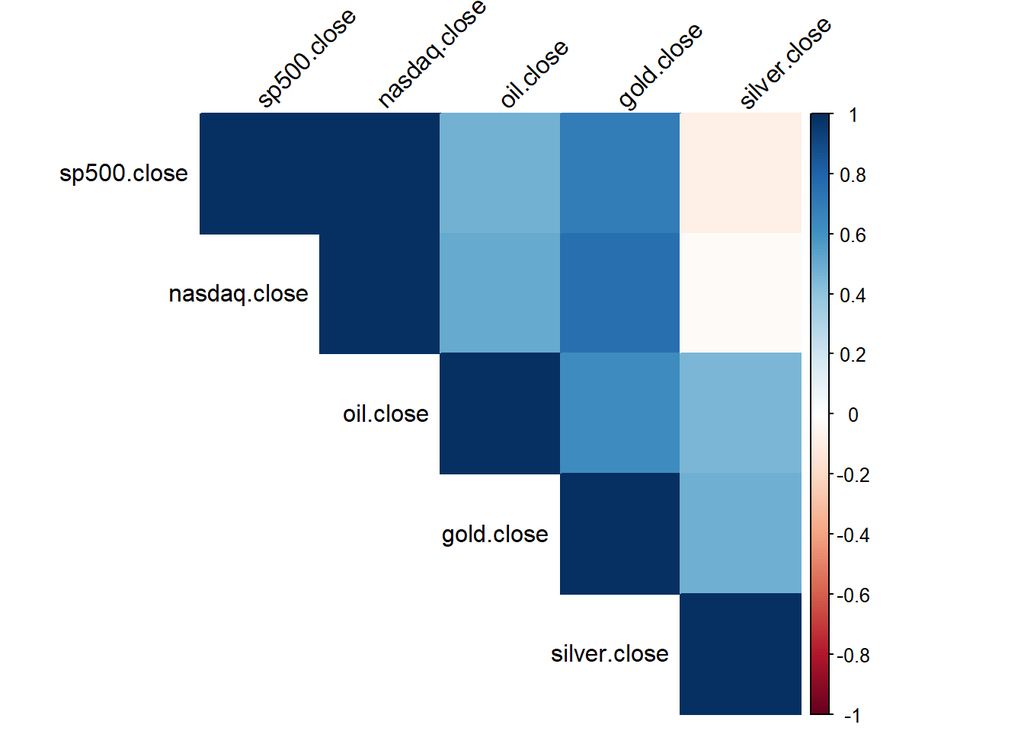

```r
# Visualize the correlation matrix
corrplot(cor_matrix, method = "color", type = "upper", tl.col = "black", tl.srt = 45)
```

`` This correlation map provides a solid snapshot of how different assets are related to each other. We are particularly looking at how the commodities are related to the S&P 500.

## S&P 500 and NASDAQ

With a score of 0.99 we can see that the S&P 500 and NASDAQ are almost perfectly positively correlated. Therefore, when the S&P 500 moves in a certain direction the NASDAQ is likely to move in the same direction.

## Correlation Summary:

High Correlation: S&P 500 and NASDAQ, NASDAQ and Gold, S&P 500 and GOLD

Moderate Correlation: S&P 500 and Oil, NASDAQ and Oil, Oil and Gold, Oil and Silver.

Weak or No Correlation: S&P 500 and Silver, NASDAQ and Silver. Due to the Market Dynamics Silver does not move in tandem with the Stock Market. Silver is more influenced by supply and demand dynamics specific to industrial and investment usages versus the stock market. Silver also tend to be highly volatile meaning weak correlation with the stock market.

```r
# Convert the date column to Date type
data_clean$date <- as.Date(data_clean$date, format = "%m/%d/%Y")

# Arrange data by date
data_clean <- data_clean %>% arrange(date)

horizon <- 5 *252

# Fit an ARIMA model to the oil closing prices
model <- auto.arima(data_clean$oil.close, seasonal = FALSE)

# Print the model summary
summary(model)
```

```
## Series: data_clean$oil.close
## ARIMA(1,0,0) with non-zero mean
##
## Coefficients:
##          ar1     mean
##       0.9394  47.2146
## s.e.  0.0553  18.4010
##
## sigma^2 = 71.02:  log likelihood = -106.55
## AIC=219.09   AICc=220.02   BIC=223.3
##
## Training set error measures:
##                     ME     RMSE      MAE       MPE     MAPE     MASE      ACF1
## Training set 0.3159122 8.141474 5.737392 -13.00707 27.23056 1.004424 0.1433156
```

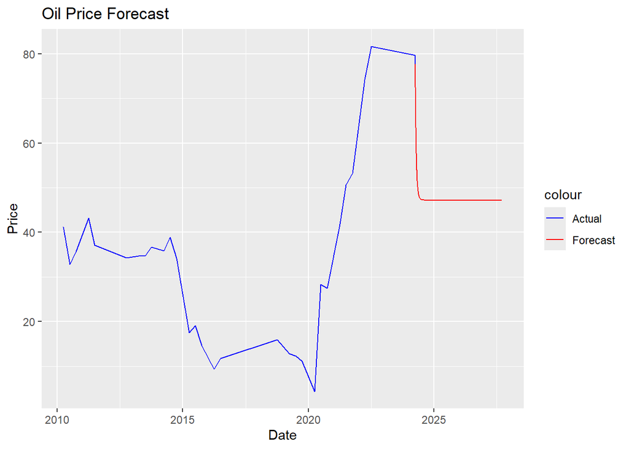

```r
# Forecast future values
forecast_values <- forecast(model, h = horizon)

# Create a data frame with the forecast values and dates
forecast_df <- data.frame(
  date = seq.Date(from = max(data_clean$date) + 1, by = "day", length.out = horizon),
  forecast = as.numeric(forecast_values$mean)
)

# Combine the actual and forecast data for plotting
plot_data <- data_clean %>%
  select(date, oil.close) %>%
  rename(actual = oil.close) %>%
  bind_rows(forecast_df %>% rename(actual = forecast))

# Plot the actual and forecasted values
ggplot(plot_data, aes(x = date)) +
  geom_line(aes(y = actual, color = "Actual")) +
  geom_line(data = forecast_df, aes(y = forecast, color = "Forecast")) +
  labs(title = "Oil Price Forecast", x = "Date", y = "Price") +
  scale_color_manual(values = c("Actual" = "blue", "Forecast" = "red"))
```

In order to forecast the movement of stocks for the future I thought the ARIMA model would be the appropriate method. The model uses previous values of the time series in order to predict future outcomes. Which I thought would be an appropriate way to predict the value of Oil in a vacuum; before I go ahead and graph the future values of the other commodities.

```r
forecast_commodity <- function(data, column_name, horizon) {
  # Fit ARIMA model
  model <- auto.arima(data[[column_name]], seasonal = FALSE)
  # Forecast future values
  forecast_values <- forecast(model, h = horizon)
  # Create a data frame with the forecast values and dates
  forecast_df <- data.frame(
    date = seq.Date(from = max(data$date) + 1, by = "day", length.out = horizon),
    forecast = as.numeric(forecast_values$mean)
  )
  return(forecast_df)
}

# Forecast for each commodity
oil_forecast <- forecast_commodity(data_clean, "oil.close", horizon)
gold_forecast <- forecast_commodity(data_clean, "gold.close", horizon)
silver_forecast <- forecast_commodity(data_clean, "silver.close", horizon)
platinum_forecast <- forecast_commodity(data_clean, "platinum.close", horizon)
palladium_forecast <- forecast_commodity(data_clean, "palladium.close", horizon)
```

```r
# Combine forecast data with historical data
combine_data <- function(data, forecast_df, column_name) {
  combined <- data %>%
    select(date, !!sym(column_name)) %>%
    rename(actual = !!sym(column_name)) %>%
    bind_rows(forecast_df %>% rename(actual = forecast))
  return(combined)
}

# Combine data for each commodity
oil_combined <- combine_data(data_clean, oil_forecast, "oil.close")
gold_combined <- combine_data(data_clean, gold_forecast, "gold.close")
silver_combined <- combine_data(data_clean, silver_forecast, "silver.close")
platinum_combined <- combine_data(data_clean, platinum_forecast, "platinum.close")
palladium_combined <- combine_data(data_clean, palladium_forecast, "palladium.close")
```

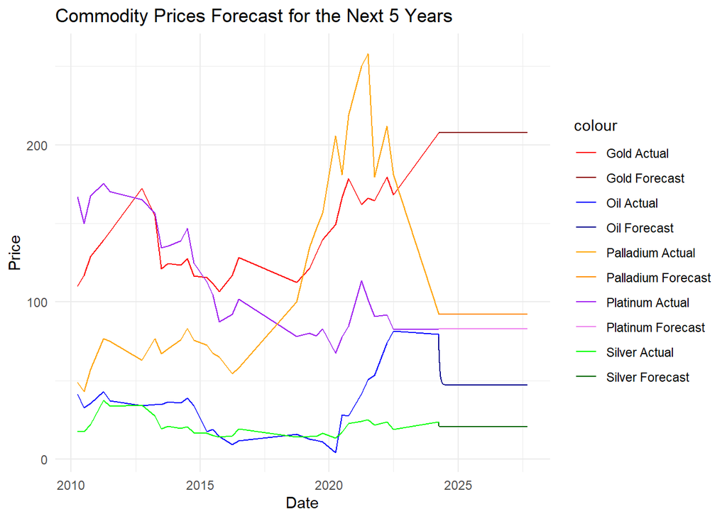

[figure not shown]

```r
# Plot the actual and forecasted values for all commodities and S&P 500
ggplot() +
  geom_line(data = oil_combined, aes(x = date, y = actual, color = "Oil Actual")) +
  geom_line(data = oil_forecast, aes(x = date, y = forecast, color = "Oil Forecast")) +
  geom_line(data = gold_combined, aes(x = date, y = actual, color = "Gold Actual")) +
  geom_line(data = gold_forecast, aes(x = date, y = forecast, color = "Gold Forecast")) +
  geom_line(data = silver_combined, aes(x = date, y = actual, color = "Silver Actual")) +
  geom_line(data = silver_forecast, aes(x = date, y = forecast, color = "Silver Forecast")) +
  geom_line(data = platinum_combined, aes(x = date, y = actual, color = "Platinum Actual")) +
  geom_line(data = platinum_forecast, aes(x = date, y = forecast, color = "Platinum Forecast")) +
  geom_line(data = palladium_combined, aes(x = date, y = actual, color = "Palladium Actual")) +
  geom_line(data = palladium_forecast, aes(x = date, y = forecast, color = "Palladium Forecast")) +
  labs(title = "Commodity Prices Forecast for the Next 5 Years",
       x = "Date", y = "Price") +
  scale_color_manual(values = c(
    "Oil Actual" = "blue", "Oil Forecast" = "darkblue",
    "Gold Actual" = "red", "Gold Forecast" = "darkred",
    "Silver Actual" = "green", "Silver Forecast" = "darkgreen",
    "Platinum Actual" = "purple", "Platinum Forecast" = "violet",
    "Palladium Actual" = "orange", "Palladium Forecast" = "darkorange"
  )) +
  theme_minimal()
```

[output not shown]

[output not shown]

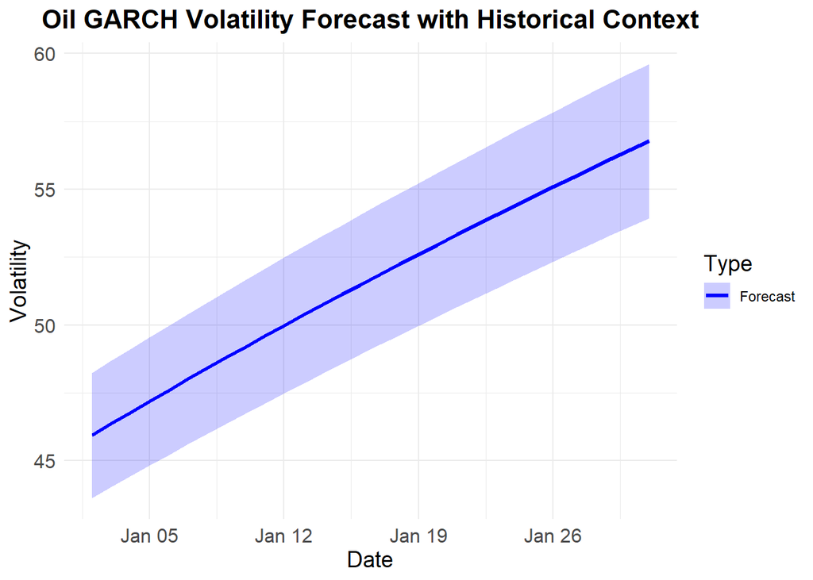

Another model I used is called the GARCH model, which is used to estimate the volatility of financial returns. Typically, it is used in markets to model and forecast the volatility of different assets. Looking at the trend line it is clear that volatility is expected to steady increase over time. You can also see that the interval increase over time, generally as the interval becomes wider it represents greater uncertainty in the forecast. Therefore, this sugests that there is uncertainty in the future. This could represent greater risks in the market for traders and investors in oil related assets.

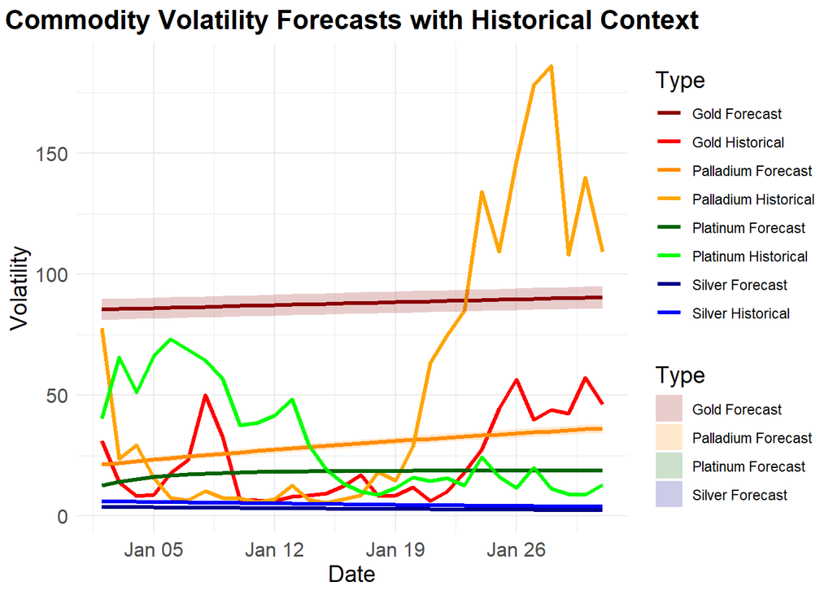

```r
# Plot the combined data with confidence intervals
ggplot(combined_data, aes(x = Date, y = Volatility, color = Type)) +
  geom_line(size = 1.2) +
  geom_ribbon(
    data = combined_data %>% filter(str_detect(Type, "Forecast")),
    aes(x = Date, ymin = Lower_CI, ymax = Upper_CI, fill = Type),
    alpha = 0.2,
    inherit.aes = FALSE
  ) +
  labs(
    title = "Commodity Volatility Forecasts with Historical Context",
    x = "Date",
    y = "Volatility",
    color = "Type",
    fill = "Type"
  ) +
  scale_color_manual(values = c(
    "Gold Historical" = "red", "Gold Forecast" = "darkred",
    "Silver Historical" = "blue", "Silver Forecast" = "darkblue",
    "Platinum Historical" = "green", "Platinum Forecast" = "darkgreen",
    "Palladium Historical" = "orange", "Palladium Forecast" = "darkorange"
  )) +
  scale_fill_manual(values = c(
    "Gold Forecast" = "darkred",
    "Silver Forecast" = "darkblue",
    "Platinum Forecast" = "darkgreen",
    "Palladium Forecast" = "darkorange"
  )) +
  theme_minimal() +
  theme(
    plot.title = element_text(hjust = 0.5, face = "bold", size = 16),
    axis.text = element_text(size = 12),
    axis.title = element_text(size = 14),
    legend.title = element_text(size = 14)
  )
```

## Important Observations

Silver has minimal volatility, with historical and forecasted levels being closely aligned, which could imply silver has a stable market.

## Potential Insights

Platinum shows moderate volatility offering a medium-risk option for investors

Palladium’s volatility signals opportunities for high-risk, high-reward strategies but will often require careful consideration of the market.